# National Adult Tobacco Survey (2009 - 2010)

**Exploratory Data Analysis**

*August 08, 2017*

*Vishal Bakshi*

*vbakshi@ccsf.edu*

Codebook: https://www.cdc.gov/tobacco/data_statistics/surveys/nats/pdfs/codebook.pdf

Weighting Methodology: https://www.cdc.gov/tobacco/data_statistics/surveys/nats/pdfs/weighting-specs.pdf

Source: https://www.cdc.gov/tobacco/data_statistics/surveys/nats/index.htm

## Objective

The National Adult Tabacco Survey (NATS) is performed by the CDC in order to gather information relevant to the habits and opinions of adults ages 18 and above in the United States. From the NATS website:

*NATS was designed as a stratified, national, landline, and cell phone survey of non-institutionalized adults aged 18 years and older residing in the 50 states or D.C. It was developed to yield data representative and comparable at both national and state levels. The sample design also aims to provide national estimates for subgroups defined by gender, age, and race/ethnicity.*

I want to perform some exploratory analysis for this survey, mainly to practice importing and cleaning data from SAS into Python, and also to explore any relationships between the different features. In this post, I focus on visualizing some of the data such as the number of cigarettes smoked per day by respondents who identified as current daily smokers, and also exploring the relationship between quit attempts and the current smoker status of the respondent.

I used the sas7bdat package located [here](https://pypi.python.org/pypi/sas7bdat) to import the original dataset into Python. I've also used and the code used in *Think Stats* by Allen B. Downey, specifically to create histograms, CDF plots and hypothesis test classes, which can be obtained at the associated [github repo](https://github.com/vishalbakshi/ThinkStats2). Code that I've either modified or written is located in the file [nats.py]

```python
from __future__ import print_function, division
from IPython.display import display, HTML

%matplotlib inline
import math
import random
import numpy as np
import pandas as pd
from sas7bdat import SAS7BDAT
import thinkstats2 as ts2
import thinkplot as tp
import matplotlib.pyplot as plt
import nats
import imp
```

```python
data, everyday, someday, former, never = nats.MakeFrames()
```

## Number of Cigarettes Per Day

The first three subsets I want to analyze are the different smoker groups defined as follows, and the data set names I gave them are in parentheses:

- Current smokers who smoke everyday. (everyday)
- Current smokers who smoke sometimes, but not everyday. (someday)
- Former smokers who had quit during the time of the interview. (former)

#### Summary Statistics: Current Daily Smokers

The first survey variable of interest was SMOKPERDAY, which is the number of cigarettes the daily smokers smoke each day. The summary statistics are shown below.

```python
nats.Summarize(everyday, None, None, 'SMOKPERDAY', 'Cigarettes per day')
```

```
Daily Smokers:
Mean: 17.187 Cigarettes per day
Variance: 103.558 Cigarettes per day ^ 2
Standard Deviation: 10.176 Cigarettes per day
```

The records in this survey are not representative on their own, but include sampling weights in order to make national and state estimates. Using the probability weights associated with national estimate representation, WT_national, the sample mean and variance are calculated as follows:

- Sample Weighted Mean:

$$\bar{x} = \frac{\sum_{i=1}^{N}w_ix_i}{\sum_{i=1}^{N}w_i}$$

- Sample Weighted Variance:

$$s^2 = \frac{V_1}{V_1^2-V_2}\sum_{i=1}^{N}w_i(x_i-\bar{x})$$

Where:

$w_i$ = Sample weights

$V_1 = \sum{w_i}$

$V_2 = \sum{w_i^2}$

In Python:

```python
def SampleMeanVarWeighted(xs, weights):
    xbar = sum(weights * xs)/sum(weights)

    v1 = sum(weights)
    v2 = sum(weights**2)
    dev = xs - xbar
    var = v1 / (v1**2 - v2)*sum(weights*dev**2)
    return xbar, var
```

```python
df = everyday.dropna(subset=['SMOKPERDAY', 'WT_national'])
xbar, var = SampleMeanVarWeighted(df.SMOKPERDAY, df.WT_national)
units = 'Cigarettes per day'
print('Weighted Sample Mean: %0.2f %s\nWeighted Sample Variance: %0.2f %s ^2' % (xbar, units, var, units))
```

```
Weighted Sample Mean: 16.73 Cigarettes per day
Weighted Sample Variance: 115.70 Cigarettes per day ^2
```

Including the sample weights causes a decrease in the sample mean and an increase in the variance and thus standard deviation.

#### Distribution of Cigarettes Per Day for Current Daily Smokers

Next, I want to visualize the distribution of SMOKPERDAY as a histogram. In order to make the histogram readable, I crop the plot window so that it shows 99% of the data. The gray line in the CDF (Cumulative Density Function) below shows the value associated with the 99th percentile of the data (50 cigarettes per day). In other words, 99% of the current daily smokers smoked less than or equal to 50 cigarettes per day. This will be the upper limit on the x-axis for the histogram.

```
everyday:
99th %-ile: 50 Cigarettes Per Day
Median: 16.00 Cigarettes Per Day
```

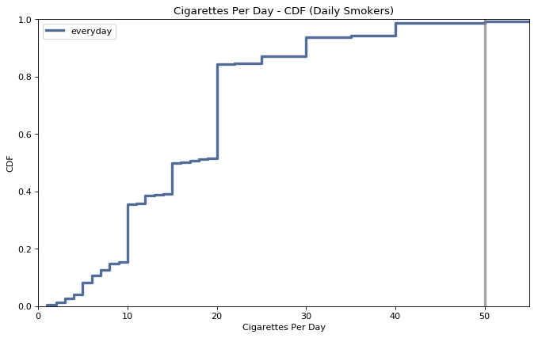

```python
plt.figure(figsize=[10, 6], dpi=80)
nats.MakeCdfPlot(everyday, 'everyday', 'SMOKPERDAY', 'Cigarettes Per Day')
tp.Config(title='Cigarettes Per Day - CDF (Daily Smokers)', axis=[0, 55, 0, 1], xlabel='Cigarettes Per Day', ylabel='CDF', legend=True)
```

```python
tp.Save(root='everyday_smokperday_cdf',
            title='Cigarettes Per Day for Daily Smokers - CDF',
            axis=[0, 55, 0, 1.0],
            xlabel='Cigarettes Per Day',
            ylabel='CDF',
            legend=True,
            formats=['pdf', 'eps'])
```

```
Writing everyday_smokperday_cdf.pdf
Writing everyday_smokperday_cdf.eps
```

Using the upper limit for the x-axis I plotted the histogram of the distribution seen below. The most frequent value is 20 cigarettes per day, which is usually the number of cigarettes in a single pack.

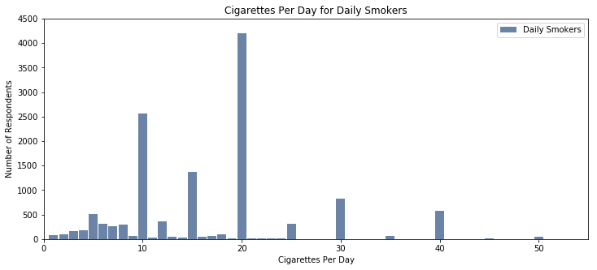

```python
plt.figure(figsize=[12, 5])
nats.MakeHist(everyday, 'Daily Smokers', 'SMOKPERDAY')
tp.Config(title='Cigarettes Per Day for Daily Smokers',
          axis=[0, 55, 0, 4500],
          xlabel='Cigarettes Per Day',
          ylabel='Number of Respondents',
          legend=True)
```

```python
tp.Save(root='everyday_smokperday',
        title='Cigarettes Per Day for Daily Smokers',
        axis=[0, 55, 0, 4500],
        xlabel='Cigarettes Per Day',
        ylabel='Number of Respondents',
        legend=True,
        formats=['pdf', 'eps'])
```

```
Writing everyday_smokperday.pdf
Writing everyday_smokperday.eps
```

## Quit Attempts by Smoker Group

The second survey variable of interest was QTATT2, the number of quit attempts for each respondent. My objective is to explore this data set and find any statistically significant differences between the three different groups of smokers.

#### Summary Statistics: Quit Attempts of Different Smoker Groups

The second variable of interest is QTATT2, the number of quit attempts by the respondent. The summary statistics for each group are shown below.

```python
nats.SummarizeWeighted(everyday, someday, former, 'QTATT2', 'Quit Attempts', True)
```

```
Daily Smokers:
Mean: 6.854 Quit Attempts
Variance: 125.367 Quit Attempts ^ 2
Standard Deviation: 11.197 Quit Attempts

Non-Daily Smokers:
Mean: 10.608 Quit Attempts
Variance: 269.081 Quit Attempts ^ 2
Standard Deviation: 16.404 Quit Attempts

Former Smokers:
Mean: 7.294 Quit Attempts
Variance: 158.133 Quit Attempts ^ 2
Standard Deviation: 12.575 Quit Attempts
```

#### Distribution of Quit Attempts for Different Smoker Groups

The distributions for this variable for the three groups of smokers are shown below--first as a comparison of CDFs and then as a comparison of histograms. Again, in order to make the histogram readable, I cropped the x-axis to omit values that were above the 99th %-ile in each group.

```
Daily Smokers:
99th %-ile: 76 Attempts
Median: 3.00 Attempts
Non-daily Smokers:
99th %-ile: 76 Attempts
Median: 5.00 Attempts
Former Smokers:
99th %-ile: 76 Attempts
Median: 4.00 Attempts
```

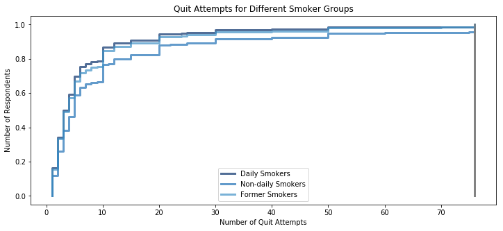

```python
tp.PrePlot(3)
plt.figure(figsize=[12, 5])
nats.MakeCdfPlot(everyday, 'Daily Smokers', 'QTATT2', 'Attempts')
nats.MakeCdfPlot(someday, 'Non-daily Smokers', 'QTATT2', 'Attempts')
nats.MakeCdfPlot(former, 'Former Smokers', 'QTATT2', 'Attempts')
tp.Config(title='Quit Attempts for Different Smoker Groups',
          xlabel='Number of Quit Attempts',
          ylabel='Number of Respondents',
          legend=True)
```

Non-daily smokers have a higher number of quit attempts overall than Daily and Former smokers. In the CDF plot, the Non-Daily smokers are slowest to reach 100%, meaning that more of the respondents in that group took a greater number of quit attempts in their life. For each group, the 99th %-ile falls at 76 quit attempts, which will be the upper limit for the histograms.

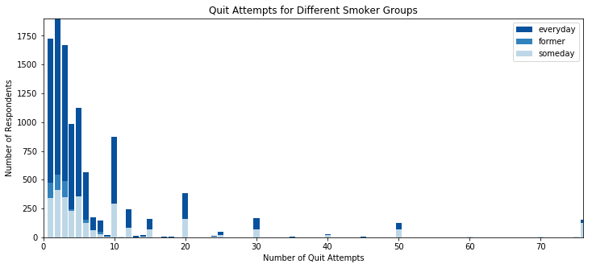

```python
tp.PrePlot(3)
plt.figure(figsize=[12, 5])

hist = ts2.Hist(everyday.QTATT2)
xs, ys = hist.Render()
plt.bar(xs, ys, color='#08519c', label='everyday')
hist = ts2.Hist(former.QTATT2)
xs, ys = hist.Render()
plt.bar(xs, ys, color='#3182bd', label='former')
hist = ts2.Hist(someday.QTATT2)
xs, ys = hist.Render()
plt.bar(xs, ys, color='#bdd7e7', label='someday')
tp.Config(axis=[0, 76, 0, 1900],
          title='Quit Attempts for Different Smoker Groups',
          xlabel='Number of Quit Attempts',
          ylabel='Number of Respondents',
          legend=True)
```

#### Preliminary Thoughts

Based on the weighted summary statistics, the difference in quit attempts between Daily Smokers and Former Smokers is apparent but small and I don't know yet if this difference is statistically significant. The difference between Non-Daily and Former Smokers is larger, but again the statistical significance must be evaluated first in order to suggest any claims.

## Hypothesis Tests

The two hypotheses that I want to explore are:

1. Is the difference in mean quit attempts between Daily and Former Smokers statistically significant?
2. Is the difference in mean quit attempts between Non-Daily and Former Smokers statistically significant?

For both hypotheses, the null hypothesis is the same:

- There is no difference in means between the two groups; they both come from the same distribution.

I'll first split the data into train and test subsets:

```python
ht_data = data.dropna(subset=['QTATT2', 'smokstatus_r'])
train = ht_data.sample(frac=0.50, random_state = 1, weights='WT_national')
test = ht_data.drop(train.index)

#Create dfs for each smoker status
every_train = train[train.smokstatus_r==1]
some_train = train[train.smokstatus_r==2]
former_train = train[train.smokstatus_r==3]

every_test = test[test.smokstatus_r==1]
some_test = test[test.smokstatus_r==2]
former_test = test[test.smokstatus_r==3]

#Summarize the train data:
nats.SummarizeWeighted(every_train, some_train, former_train, 'QTATT2', 'Quit Attempts', True)
```

```
Daily Smokers:
Mean: 6.776 Quit Attempts
Variance: 122.417 Quit Attempts ^ 2
Standard Deviation: 11.064 Quit Attempts

Non-Daily Smokers:
Mean: 10.412 Quit Attempts
Variance: 257.770 Quit Attempts ^ 2
Standard Deviation: 16.055 Quit Attempts

Former Smokers:
Mean: 7.056 Quit Attempts
Variance: 153.778 Quit Attempts ^ 2
Standard Deviation: 12.401 Quit Attempts
```

The difference in weighted mean between Daily smokers and Former smokers is given by:

```python
daily_mean, _ = nats.SampleMeanVarWeighted(every_train.QTATT2, every_train.WT_national)
former_mean, _ = nats.SampleMeanVarWeighted(former_train.QTATT2, former_train.WT_national)
train_stat1 = abs(daily_mean - former_mean)
train_stat1
```

```
0.28037329250861376
```

In `nats.py` I've used the code for a hypothesis test similar to the one written by Allen B. Downey in *Think Stats* which you can see [here](https://github.com/AllenDowney/ThinkStats2/blob/master/code/hypothesis.py) and [here](https://github.com/AllenDowney/ThinkStats2/blob/master/code/thinkstats2.py). The HypothesisTest class contains a method `MakeModel` which creates the null hypothesis, that the distribution of quit attempts between two groups comes from the same distribution, by combining the data from the two groups into one array using `np.hstack`. The `RunModel` method splits the combined distribution into two arrays using the lengths of the original groups, and sends that data to the `TestStatistic` method which calculates the (absolute value) difference in mean between the two groups. The `PValue` method runs this model for a default 1000 times, and counts how many iterations resulted in an absolute value difference in mean greater than the train data result. I wrote a DiffMeansTest class which takes the test set of dat and the difference in mean from the train set:

```python
class DiffMeansTest(ts2.HypothesisTest):
    def __init__(self, data, train_stat):
        """Initializes.

        data: pandas Series from two different smoker groups
        """
        self.data = data
        self.MakeModel()
        self.actual = train_stat
        self.test_stats = None
        self.Cdf = None

    def MakeModel(self):
        """Builds a model of the null hypothesis."""
        group1, group2 = self.data
        self.n, self.m = len(group1), len(group2)
        self.pool = np.hstack((group1, group2))

    def RunModel(self):
        """Run a model of the null hypothesis.

        returns: simulated data (two groups)
        """
        np.random.shuffle(self.pool)
        data = self.pool[:self.n], self.pool[self.n:]
        return data

    def TestStatistic(self, data):
        """Computes the test statistic.

        data: two pandas Series
        """
        group1, group2 = data
        test_stat = abs(group1.mean() - group2.mean())
        return test_stat

    def PValue(self, iters=1000):
        """Computes the distribution of the test statistic and p-value.

        iters: number of iterations
        returns: float p-value
        """
        self.test_stats = [self.TestStatistic(self.RunModel()) for _ in range(iters)]
        self.test_cdf = ts2.Cdf(self.test_stats)

        count = sum(1 for x in self.test_stats if x>= self.actual)
        return count / iters
```

Running this hypothesis test with the test data for Daily smokers and Former smokers:

```python
ht1 = DiffMeansTest((every_test.QTATT2, former_test.QTATT2), train_stat1)
ht1.PValue()
```

```
0.386
```

The resulting p-value is well above the 1% threshold, so based on this test model, the null hypothesis cannot be rejected. I also ran the hypothesis test with the test data for Daily smokers and Non-daily smokers:

```python
daily_mean, _ = nats.SampleMeanVarWeighted(every_train.QTATT2, every_train.WT_national)
some_mean, _ = nats.SampleMeanVarWeighted(some_train.QTATT2, some_train.WT_national)
train_stat2 = abs(daily_mean - some_mean)
train_stat2
```

```
3.636241487918018
```

```python
ht2 = DiffMeansTest((every_test.QTATT2, some_test.QTATT2), train_stat2)
ht2.PValue()
```

```
0.0
```

```python
some_mean, _ = nats.SampleMeanVarWeighted(some_train.QTATT2, some_train.WT_national)
former_mean, _ = nats.SampleMeanVarWeighted(former_train.QTATT2, former_train.WT_national)
train_stat3 = abs(some_mean - former_mean)
train_stat3
```

```
3.3558681954094043
```

```python
ht3 = DiffMeansTest((every_test.QTATT2, some_test.QTATT2), train_stat3)
ht3.PValue()
```

```
0.0
```

Again, the p-value in this case is smaller than the 1% threshold. The results for the three tests are summarized below:

[output not shown]

#### Sampling Distribution of Weighted Means

Another source of uncertainty is the value of the weighted mean for the different smoker groups. The weighted means used as the test-statistic are summarized below:

| Group | Weighted Mean of Quit Attempts |
| --- | --- |
| Daily Smokers | 6.78 |
| Non-daily Smokers | 10.41 |
| Former Smokers | 7.06 |

I want to create the sampling distribution for this estimate, resampling each group using the national weights as the sampling probabilities, and plotting the distribution of the estimates:

```python
def ResampleRowsWeighted(df, column='WT_national'):
    """Resamples a DataFrame using probabilities proportional to given column.

    df: DataFrame
    column: string column name to use as weights

    returns: DataFrame
    """
    weights = df[column].copy()
    weights /= sum(weights)
    indices = np.random.choice(df.index, len(df), replace=True, p=weights)
    sample = df.loc[indices]
    return sample
```

```python
iters = 1000
daily_means = [ResampleRowsWeighted(every_train).QTATT2.mean() for _ in range(iters)]
some_means = [ResampleRowsWeighted(some_train).QTATT2.mean() for _ in range(iters)]
former_means = [ResampleRowsWeighted(former_train).QTATT2.mean() for _ in range(iters)]
```

```python
def PlotSamplingDistribution(series, label=''):
    cdf = ts2.Cdf(series)
    ci = cdf.Value(0.05), cdf.Value(0.95)
    tp.Cdf(cdf, label=label)
    nats.VertLine(ci[0])
    nats.VertLine(ci[1])
    print('%s - 90%% CI: (%0.3f, %0.3f)' % (label, ci[0], ci[1]))
```

```
Daily Smokers - 90% CI: (6.520, 7.035)
Non-Daily Smokers - 90% CI: (9.701, 11.136)
Former Smokers - 90% CI: (6.529, 7.557)
```

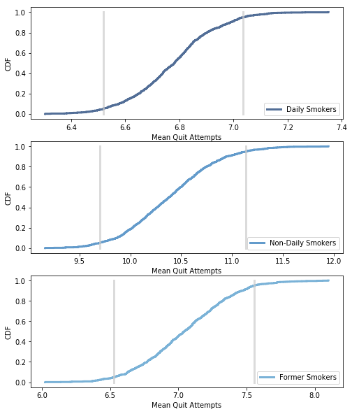

```python
dists = [daily_means, some_means, former_means]
labels = ['Daily Smokers', 'Non-Daily Smokers', 'Former Smokers']
tp.PrePlot(rows=3)
groups = zip(dists, labels)
for i, (dist, label) in enumerate(groups):
    tp.SubPlot(i+1)
    PlotSamplingDistribution(dist, label)
    tp.Config(xlabel='Mean Quit Attempts', ylabel='CDF', legend=True)
```

The variation in the sample mean will cause a variation in the p-values as well.

## Future Explorations

This analysis helped identified some interesting and possibly releavent relationships between quit attempts and smoker status, but further analysis is necessary (either with different models and/or with later cycles of the NATS) in order to give stronger evidence for any claims. I would also like to explore the relationships in future posts between smoker status and the following factors (NATS variable name shown in parenthesis):

- Employement Status (EMPLOY2)
- Number of jobs held (NOJOBS)
- Household Income (INCOME2)
- Race (RACEETHNIC)
- Use of cessation meds such as sprays, lozenges, etc. (QTMED2)
- Use of other forms of tobacco (chew, snus, cigars, etc) (Sltever2_r, currentslt_r, Snusever_r, Cigarever_r)
- Marriage status (MARITAL2)
- Healthcare coverage (HCCOVERAG)

Questions/Comments: vbakshi@ccsf.edu